# Recheck the correlation approach for ICC estimation

- Show All Code
- Hide All Code
- View Source

Author

Tzu-Yao Lin

Published

December 17, 2025

# 1 Setup

Load necessary packages.

```r
library(tidyverse)
theme_set(theme_bw() +
          theme(aspect.ratio = 1))
library(furrr)
plan(multisession, workers = 8)
library(irr)
library(psych)
library(gt)
set.seed(20251210)
```

# 2 Recheck the correlation approach

> A rigorous definition is adopted for the ICC, namely, that the ICC is the correlation between one measurement (either a single rating or a mean of several ratings) on a target and another measurement obtained on that target. The ICC is thus a bona fide correlation coefficient that, as is shown below, is of ten but not necessarily identical to the component of variance due to targets divided by the sum of it and other variance components (Shrout & Fleiss, 1979).

The following codes are functions to simulate data under five different ANOVA models and compute the ICC as the correlation between two measurements on the same target or cluster. If the effects are random effects, they are independently generated for the two measurements. If the effects are fixed effects, they are held constant across the all replications (`rep_size`).

**Note**

Please check the handwritten notes first for the simulation procedures.

```r
oneway_icc <- function(pars,
                       unit = c("single", "average"),
                       rep_size = 1000) {
  if (is.null(pars$mu)) {mu <- 0} else {mu <- pars$mu}
  if (is.null(pars$sigma_S)) {stop("sigma_S need to be specified")}
  if (is.null(pars$sigma_E)) {stop("sigma_E need to be specified")}
  if (is.null(pars$M)) {stop("M need to be specified")}

  sigma_S <- pars$sigma_S
  sigma_E <- pars$sigma_E
  M <- pars$M
  num_ave_R <- ifelse(unit == "single", 1, M)

  #
  y_ij1 <- vector("double", length = rep_size)
  y_ij2 <- vector("double", length = rep_size)

  for (l in seq_len(rep_size)) {
    S_i <- rnorm(1, 0, sigma_S)
    E_ij1 <- rnorm(num_ave_R, 0, sigma_E)
    E_ij2 <- rnorm(num_ave_R, 0, sigma_E)
    y_ij1[l] <- mu + S_i + mean(E_ij1)
    y_ij2[l] <- mu + S_i + mean(E_ij2)
  }

  return(cor(y_ij1, y_ij2))
}

twoway_random_icc <- function(pars,
                              type = c("agreement", "consistency"),
                              unit = c("single", "average"),
                              rep_size = 1000) {

  if (is.null(pars$mu)) {mu <- 0} else {mu <- pars$mu}
  if (is.null(pars$sigma_S)) {stop("sigma_S need to be specified")}
  if (is.null(pars$sigma_R)) {stop("sigma_R need to be specified")}
  if (is.null(pars$sigma_E)) {stop("sigma_E need to be specified")}
  if (is.null(pars$M)) {stop("M need to be specified")}

  sigma_S <- pars$sigma_S
  sigma_E <- pars$sigma_E
  sigma_R <- pars$sigma_R
  M <- pars$M
  num_ave_R <- ifelse(unit == "single", 1, M)

  #
  y_ij1 <- vector("double", length = rep_size)
  y_ij2 <- vector("double", length = rep_size)

  if (type == "agreement") {
    for (l in seq_len(rep_size)) {
      S_i <- rnorm(1, 0, sigma_S)
      R_j1 <- rnorm(num_ave_R, 0, sigma_R)
      R_j2 <- rnorm(num_ave_R, 0, sigma_R)
      E_ij1 <- rnorm(num_ave_R, 0, sigma_E)
      E_ij2 <- rnorm(num_ave_R, 0, sigma_E)
      y_ij1[l] <- mu + S_i + mean(R_j1) + mean(E_ij1)
      y_ij2[l] <- mu + S_i + mean(R_j2) + mean(E_ij2)
    }
  } else if (type == "consistency") {
    # rater effects are fixed across measurements
    R_j1 <- rnorm(num_ave_R, 0, sigma_R)
    R_j2 <- rnorm(num_ave_R, 0, sigma_R)

    # other random effects are independently generated
    for (l in seq_len(rep_size)) {
      S_i <- rnorm(1, 0, sigma_S)
      E_ij1 <- rnorm(num_ave_R, 0, sigma_E)
      E_ij2 <- rnorm(num_ave_R, 0, sigma_E)
      y_ij1[l] <- mu + S_i + mean(R_j1) + mean(E_ij1)
      y_ij2[l] <- mu + S_i + mean(R_j2) + mean(E_ij2)
    }
  }

  return(cor(y_ij1, y_ij2))
}

twoway_mixed_icc <- function(pars,
                             type = c("agreement", "consistency"),
                             unit = c("single", "average"),
                             rep_size = 1000) {
  if (is.null(pars$mu)) {mu <- 0} else {mu <- pars$mu}
  if (is.null(pars$sigma_S)) {stop("sigma_S need to be specified")}
  if (is.null(pars$theta_R)) {stop("theta_R need to be specified")}
  if (is.null(pars$sigma_E)) {stop("sigma_E need to be specified")}
  if (is.null(pars$M)) {stop("M need to be specified")}

  sigma_S <- pars$sigma_S
  theta_R <- pars$theta_R
  sigma_E <- pars$sigma_E
  M <- pars$M
  num_ave_R <- ifelse(unit == "single", 1, M)

  #
  y_ij1 <- vector("double", length = rep_size)
  y_ij2 <- vector("double", length = rep_size)

  # rater effects are fixed in all scenarios
  R_j <- MASS::mvrnorm(M, 0, theta_R^2, empirical = TRUE) |> as.vector()

  if (type == "agreement") {

    for (l in seq_len(rep_size)) {
      if (unit == "single") {
        selected_R_j1j2 <- sample(M, 2, replace = FALSE)
      } else {
        selected_R_j1j2 <- 1:M # actually, everyone have the same group of raters, Ak == Ck
      }
      S_i <- rnorm(1, 0, sigma_S)
      R_j1 <- R_j[selected_R_j1j2[1]]
      R_j2 <- R_j[selected_R_j1j2[2]]
      E_ij1 <- rnorm(num_ave_R, 0, sigma_E)
      E_ij2 <- rnorm(num_ave_R, 0, sigma_E)
      y_ij1[l] <- mu + S_i + mean(R_j1) + mean(E_ij1)
      y_ij2[l] <- mu + S_i + mean(R_j2) + mean(E_ij2)
    }
  } else if (type == "consistency") {
    # rater effects are fixed across measurements
    if (unit == "single") {
      selected_R_j1j2 <- sample(M, 2, replace = FALSE)
    } else {
      selected_R_j1j2 <- 1:M # actually, everyone have the same group of raters, Ak == Ck
    }

    R_j1 <- R_j[selected_R_j1j2[1]]
    R_j2 <- R_j[selected_R_j1j2[2]]

    # other random effects are independently generated
    for (l in seq_len(rep_size)) {
      S_i <- rnorm(1, 0, sigma_S)
      E_ij1 <- rnorm(num_ave_R, 0, sigma_E)
      E_ij2 <- rnorm(num_ave_R, 0, sigma_E)
      y_ij1[l] <- mu + S_i + mean(R_j1) + mean(E_ij1)
      y_ij2[l] <- mu + S_i + mean(R_j2) + mean(E_ij2)
    }
  }

  return(cor(y_ij1, y_ij2))
}

threeway_nested_icc <- function(pars,
                                unit = c("single", "average"),
                                level = c("cluster", "subject"),
                                clus_score_form = c("manifest", "latent"),
                                rep_size = 1000) {
  if (is.null(pars$mu)) {mu <- 0} else {mu <- pars$mu}
  if (is.null(pars$sigma_C)) {stop("sigma_C need to be specified")}
  if (is.null(pars$sigma_S)) {stop("sigma_S need to be specified")}
  if (is.null(pars$sigma_E)) {stop("sigma_E need to be specified")}
  if (is.null(pars$N)) {stop("N (number of subjects) need to be specified")}
  if (is.null(pars$M)) {stop("M (number of raters) need to be specified")}

  sigma_C <- pars$sigma_C
  sigma_S <- pars$sigma_S
  sigma_E <- pars$sigma_E
  N <- pars$N
  M <- pars$M
  num_ave_S <- ifelse(unit == "single", 1, N)
  num_ave_R <- ifelse(unit == "single", 1, M)

  #
  y_kij1 <- vector("double", length = rep_size)
  y_kij2 <- vector("double", length = rep_size)

  if (level == "subject") {
    # condition on a specific cluster
    C_k <- rnorm(1, 0, sigma_C)

    for (l in seq_len(rep_size)) {
      S_ki <- rnorm(1, 0, sigma_S)
      E_kij1 <- rnorm(num_ave_R, 0, sigma_E)
      E_kij2 <- rnorm(num_ave_R, 0, sigma_E)
      y_kij1[l] <- mu + C_k + S_ki + mean(E_kij1)
      y_kij2[l] <- mu + C_k + S_ki + mean(E_kij2)
    }
```

```r
  } else if (level == "cluster") {

    if (clus_score_form == "manifest") {

      for (l in seq_len(rep_size)) {
        C_k <- rnorm(1, 0, sigma_C)
        S_ki1 <- rnorm(num_ave_S, 0, sigma_S)
        S_ki2 <- rnorm(num_ave_S, 0, sigma_S)
        E_kij1 <- rnorm(num_ave_S * num_ave_R, 0, sigma_E)
        E_kij2 <- rnorm(num_ave_S * num_ave_R, 0, sigma_E)
        y_kij1[l] <- mu + C_k + mean(S_ki1) + mean(E_kij1)
        y_kij2[l] <- mu + C_k + mean(S_ki2) + mean(E_kij2)
      }

    } else if (clus_score_form == "latent") {

      # condition on a specific subject (to remove its effect) as if this subject can show up in different clusters
      S_ki <- rnorm(num_ave_S, 0, sigma_S)

      for (l in seq_len(rep_size)) {
        C_k <- rnorm(1, 0, sigma_C)
        E_kij1 <- rnorm(num_ave_S * num_ave_R, 0, sigma_E)
        E_kij2 <- rnorm(num_ave_S * num_ave_R, 0, sigma_E)
        y_kij1[l] <- mu + C_k + mean(S_ki) + mean(E_kij1)
        y_kij2[l] <- mu + C_k + mean(S_ki) + mean(E_kij2)
      }

    }
  }

  return(cor(y_kij1, y_kij2))
}

threeway_nestcrossed_icc <- function(pars,
                                     type = c("absolute", "consistency"),
                                     unit = c("single", "average"),
                                     level = c("cluster", "subject"),
                                     clus_score_form = c("manifest", "latent"),
                                     rep_size = 1000) {
  if (is.null(pars$mu)) {mu <- 0} else {mu <- pars$mu}
  if (is.null(pars$sigma_C)) {stop("sigma_C need to be specified")}
  if (is.null(pars$sigma_S)) {stop("sigma_S need to be specified")}
  if (is.null(pars$sigma_R)) {stop("sigma_R need to be specified")}
  if (is.null(pars$sigma_CR)) {stop("sigma_CR need to be specified")}
  if (is.null(pars$sigma_E)) {stop("sigma_E need to be specified")}
  if (is.null(pars$N)) {stop("N (number of subjects) need to be specified")}
  if (is.null(pars$M)) {stop("M (number of raters) need to be specified")}

  sigma_C <- pars$sigma_C
  sigma_S <- pars$sigma_S
  sigma_R <- pars$sigma_R
  sigma_CR <- pars$sigma_CR
  sigma_E <- pars$sigma_E
  N <- pars$N
  M <- pars$M
  num_ave_S <- ifelse(unit == "single", 1, N)
  num_ave_R <- ifelse(unit == "single", 1, M)

  #
  y_kij1 <- vector("double", length = rep_size)
  y_kij2 <- vector("double", length = rep_size)

  if (level == "subject") {
    # condition on a specific cluster
    C_k <- rnorm(1, 0, sigma_C)

    if (type == "agreement") {

      for (l in seq_len(rep_size)) {
        S_ki <- rnorm(1, 0, sigma_S)
        R_j1 <- rnorm(num_ave_R, 0, sigma_R)
        R_j2 <- rnorm(num_ave_R, 0, sigma_R)
        CR_kj1 <- rnorm(num_ave_R, 0, sigma_CR)
        CR_kj2 <- rnorm(num_ave_R, 0, sigma_CR)
        E_kij1 <- rnorm(num_ave_R, 0, sigma_E)
        E_kij2 <- rnorm(num_ave_R, 0, sigma_E)
        y_kij1[l] <- mu + C_k + S_ki + mean(R_j1) + mean(CR_kj1) + mean(E_kij1)
        y_kij2[l] <- mu + C_k + S_ki + mean(R_j2) + mean(CR_kj2) + mean(E_kij2)
      }

    } else if (type == "consistency") {
      # rater-related effects are fixed across measurements
      R_j1 <- rnorm(num_ave_R, 0, sigma_R)
      R_j2 <- rnorm(num_ave_R, 0, sigma_R)
      CR_kj1 <- rnorm(num_ave_R, 0, sigma_CR)
      CR_kj2 <- rnorm(num_ave_R, 0, sigma_CR)

      for (l in seq_len(rep_size)) {
        S_ki <- rnorm(1, 0, sigma_S)
        E_kij1 <- rnorm(num_ave_R, 0, sigma_E)
        E_kij2 <- rnorm(num_ave_R, 0, sigma_E)
        y_kij1[l] <- mu + C_k + S_ki + mean(R_j1) + mean(CR_kj1) + mean(E_kij1)
        y_kij2[l] <- mu + C_k + S_ki + mean(R_j2) + mean(CR_kj2) + mean(E_kij2)
      }
    }


  } else if (level == "cluster") {

    if (clus_score_form == "manifest") {

      if (type == "agreement") {

        for (l in seq_len(rep_size)) {
          C_k <- rnorm(1, 0, sigma_C)
          S_ki1 <- rnorm(num_ave_S, 0, sigma_S)
          S_ki2 <- rnorm(num_ave_S, 0, sigma_S)
          R_j1 <- rnorm(num_ave_R, 0, sigma_R)
          R_j2 <- rnorm(num_ave_R, 0, sigma_R)
          CR_kj1 <- rnorm(num_ave_R, 0, sigma_CR)
          CR_kj2 <- rnorm(num_ave_R, 0, sigma_CR)
          E_kij1 <- rnorm(num_ave_S * num_ave_R, 0, sigma_E)
          E_kij2 <- rnorm(num_ave_S * num_ave_R, 0, sigma_E)
          y_kij1[l] <- mu + C_k + mean(S_ki1) + mean(R_j1) + mean(CR_kj1) + mean(E_kij1)
          y_kij2[l] <- mu + C_k + mean(S_ki2) + mean(R_j2) + mean(CR_kj2) + mean(E_kij2)
        }

      } else if (type == "consistency") {
        # rater-related effects are fixed across measurements
        R_j1 <- rnorm(num_ave_R, 0, sigma_R)
        R_j2 <- rnorm(num_ave_R, 0, sigma_R)

        for (l in seq_len(rep_size)) {
          C_k <- rnorm(1, 0, sigma_C)
          S_ki1 <- rnorm(num_ave_S, 0, sigma_S)
          S_ki2 <- rnorm(num_ave_S, 0, sigma_S)
          CR_kj1 <- rnorm(num_ave_R, 0, sigma_CR) # C is still random -> CR random
          CR_kj2 <- rnorm(num_ave_R, 0, sigma_CR)
          E_kij1 <- rnorm(num_ave_S * num_ave_R, 0, sigma_E)
          E_kij2 <- rnorm(num_ave_S * num_ave_R, 0, sigma_E)
          y_kij1[l] <- mu + C_k + mean(S_ki1) + mean(R_j1) + mean(CR_kj1) + mean(E_kij1)
          y_kij2[l] <- mu + C_k + mean(S_ki2) + mean(R_j2) + mean(CR_kj2) + mean(E_kij2)
        }

      }

    } else if (clus_score_form == "latent") {
      # condition on a specific subject (to remove its effect) as if this subject can show up in different clusters
      S_ki <- rnorm(num_ave_S, 0, sigma_S)

      if (type == "agreement") {

        for (l in seq_len(rep_size)) {
          C_k <- rnorm(1, 0, sigma_C)
          R_j1 <- rnorm(num_ave_R, 0, sigma_R)
          R_j2 <- rnorm(num_ave_R, 0, sigma_R)
          CR_kj1 <- rnorm(num_ave_R, 0, sigma_CR)
          CR_kj2 <- rnorm(num_ave_R, 0, sigma_CR)
          E_kij1 <- rnorm(num_ave_S * num_ave_R, 0, sigma_E)
          E_kij2 <- rnorm(num_ave_S * num_ave_R, 0, sigma_E)
          y_kij1[l] <- mu + C_k + mean(S_ki) + mean(R_j1) + mean(CR_kj1) + mean(E_kij1)
          y_kij2[l] <- mu + C_k + mean(S_ki) + mean(R_j2) + mean(CR_kj2) + mean(E_kij2)
        }
```

```r
      } else if (type == "consistency") {
        # rater-related effects are fixed across measurements
        R_j1 <- rnorm(num_ave_R, 0, sigma_R)
        R_j2 <- rnorm(num_ave_R, 0, sigma_R)

        for (l in seq_len(rep_size)) {
          C_k <- rnorm(1, 0, sigma_C)
          CR_kj1 <- rnorm(num_ave_R, 0, sigma_CR) # C is still random -> CR random
          CR_kj2 <- rnorm(num_ave_R, 0, sigma_CR)
          E_kij1 <- rnorm(num_ave_S * num_ave_R, 0, sigma_E)
          E_kij2 <- rnorm(num_ave_S * num_ave_R, 0, sigma_E)
          y_kij1[l] <- mu + C_k + mean(S_ki) + mean(R_j1) + mean(CR_kj1) + mean(E_kij1)
          y_kij2[l] <- mu + C_k + mean(S_ki) + mean(R_j2) + mean(CR_kj2) + mean(E_kij2)
        }

      }
    }
  }

  return(cor(y_kij1, y_kij2))
}
```

```r
icc_cor <- function(pars,
                    model = c("oneway", "twoway-random", "twoway-mixed", "threeway-nested", "threeway-nestcrossed"),
                    type = c("agreement", "consistency"),
                    unit = c("single", "average"),
                    level = c("cluster", "subject"),
                    clus_score_form = c("manifest", "latent"),
                    rep_size = 1000) {
  model <- match.arg(model)
  type <- match.arg(type)
  unit <- match.arg(unit)
  level <- match.arg(level)
  clus_score_form <- match.arg(clus_score_form)

  icc <- switch(model,
    "oneway" = oneway_icc(pars, unit, rep_size),
    "twoway-random" = twoway_random_icc(pars, type, unit, rep_size),
    "twoway-mixed" = twoway_mixed_icc(pars, type, unit, rep_size),
    "threeway-nested" = threeway_nested_icc(pars, unit, level, clus_score_form, rep_size),
    "threeway-nestcrossed" = threeway_nestcrossed_icc(pars, type, unit, level, clus_score_form, rep_size)
  )

  return(icc)
}
```

## 2.1 Case 1: One-way ANOVA (Classcial Test Theory)

Subject: $i = 1, \dots, N$, Raters: $j = 1, \dots, M$ which are nested within subjects.

$$Y_{(j)i} = T_i + E_{(j)i} = \mu + S_i + E_{(j)i}$$

where

- $T_i = E_{J}[Y_{(j)i}] = \mu + S_i$
- $S_i \sim N(0, \sigma_S^2)$
- $E_{(j)i} \sim N(0, \sigma_E^2)$

The ICC formulas:

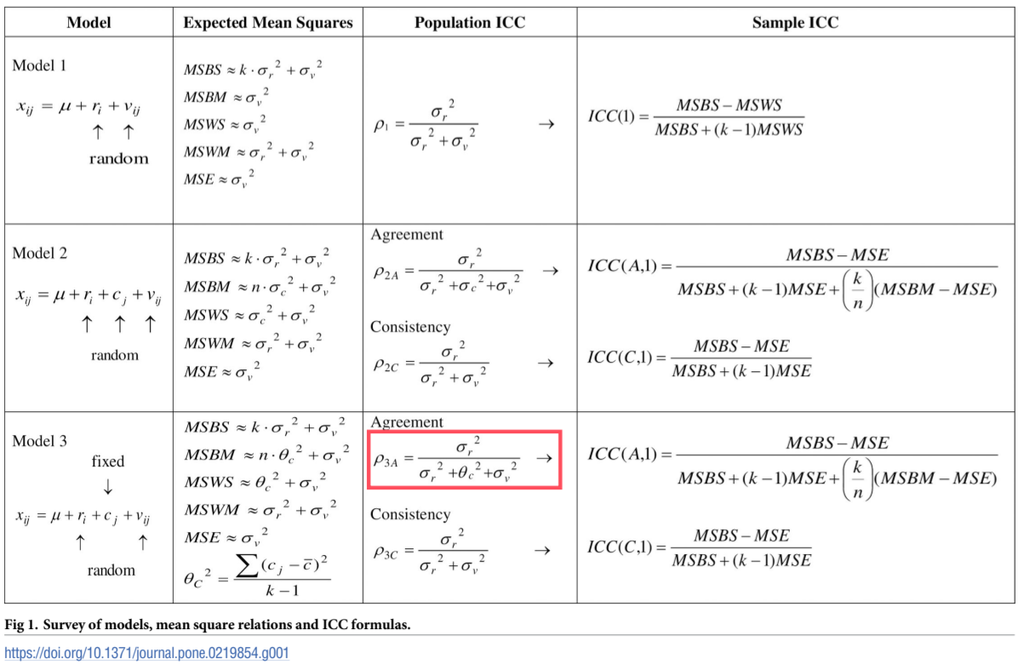

ICC formulas for Cases 1, 2, and 3 (Table retrived form Liljequist et al., 2019)

**Simplyly check the ICC calculations**

```r
# parameters
M <- 3
sigma_S <- 3
sigma_E <- 2
pars_case1 = list(mu = 2, sigma_S = sigma_S, sigma_E = sigma_E, M = M)

# results
case1_table <- tibble(
  Reliability = c("ICC(1)", "ICC(k)"),
  Setting = c(
    sigma_S^2 / (sigma_S^2 + sigma_E^2),
    sigma_S^2 / (sigma_S^2 + sigma_E^2 / M)
  ),
  Simulation = c(
    icc_cor(pars = pars_case1, model = "oneway", unit = "single", rep_size = 10000),
    icc_cor(pars = pars_case1, model = "oneway", unit = "average", rep_size = 10000)
  )
) |>
  mutate(across(where(is.numeric), ~ round(., 4)))

gt(case1_table)
```

| Reliability | Setting | Simulation |
| --- | --- | --- |
| ICC(1) | 0.6923 | 0.6917 |
| ICC(k) | 0.8710 | 0.8709 |

**Simulation under different scenarios**

```r
rep_size <- c(100, 1000, 10000)
M <- c(5, 30, 50)
sigma_E <- c(1, 3, 5)
sigma_SE_ratio <- c(0.5, 1, 2)

case1_sim <-
  expand_grid(
    rep_size = rep_size,
    M = M,
    sigma_E = sigma_E,
    sigma_SE_ratio = sigma_SE_ratio
  ) |>
  mutate(
    sigma_S = sigma_SE_ratio * sigma_E,
    pars = list_transpose(list(sigma_S = sigma_S, sigma_E = sigma_E, M = M), simplify = FALSE),
    ICC_1 = sigma_S^2 / (sigma_S^2 + sigma_E^2),
    ICC_k = sigma_S^2 / (sigma_S^2 + sigma_E^2 / M),
    icc_1 = future_map2_dbl(
      pars, rep_size,
      ~ icc_cor(pars = .x, model = "oneway", unit = "single", rep_size = .y),
      .options = furrr_options(seed = TRUE)
    ),
    icc_k = future_map2_dbl(
      pars, rep_size,
      ~ icc_cor(pars = .x, model = "oneway", unit = "average", rep_size = .y),
      .options = furrr_options(seed = TRUE)
    )
  )
```

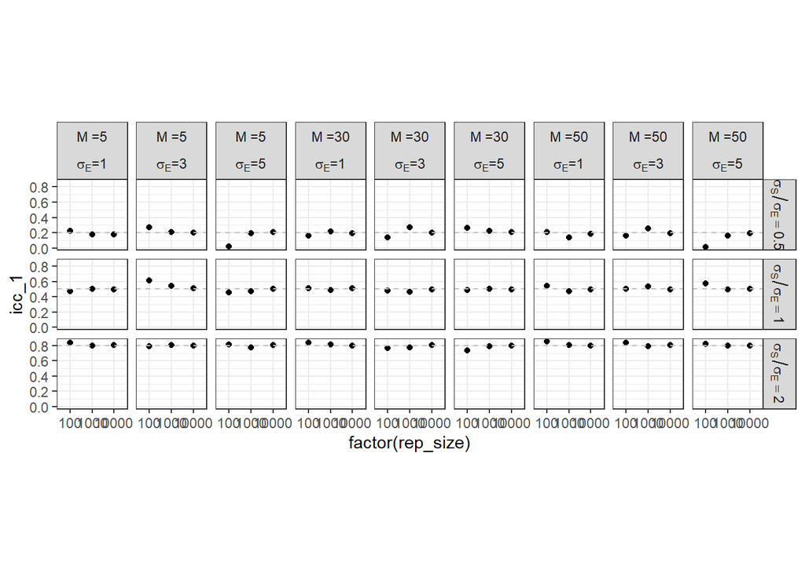

Figure 1: ICC(1) for Case 1

```r
case1_sim |>
  select(rep_size, M, sigma_E, sigma_SE_ratio, ICC_1, icc_1) |>
  ggplot(aes(x = factor(rep_size), y = icc_1)) +
  geom_point() +
  geom_hline(aes(yintercept = ICC_1), linetype = "dashed", color = "gray") +
  facet_grid(sigma_SE_ratio ~ M + sigma_E,
             labeller = label_bquote(rows = sigma[S]/sigma[E] == .(sigma_SE_ratio),
                                     cols = atop(paste("M =", .(M)),
                                                 paste(sigma[E], "=", .(sigma_E)))))
```

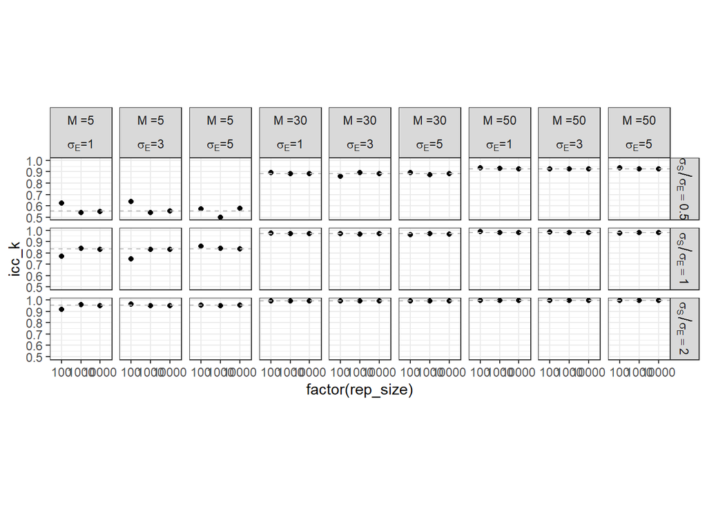

Figure 2: ICC(k) for Case 1

```r
case1_sim |>
  select(rep_size, M, sigma_E, sigma_SE_ratio, ICC_k, icc_k) |>
  ggplot(aes(x = factor(rep_size), y = icc_k)) +
  geom_point() +
  geom_hline(aes(yintercept = ICC_k), linetype = "dashed", color = "gray") +
  facet_grid(sigma_SE_ratio ~ M + sigma_E,
             labeller = label_bquote(rows = sigma[S]/sigma[E] == .(sigma_SE_ratio),
                                     cols = atop(paste("M =", .(M)),
                                                 paste(sigma[E], "=", .(sigma_E)))))
```

## 2.2 Case 2: Two-way Random-Effect ANOVA

Subject: $i = 1, \dots, N$, Raters: $j = 1, \dots, M$. Subjects and raters are both random effects and crossed with each other.

$$Y_{ij} = \mu + S_i + R_j + (SR_{ij} + E_{ij}^*) = \mu + S_i + R_j + E_{ij}$$

where

- $S_i \sim N(0, \sigma_S^2)$
- $R_j \sim N(0, \sigma_R^2)$
- $E_{ij} \sim N(0, \sigma_E^2)$

and we don’t distinguish the interaction and residual error here.

**Simply check the ICC calculations**

```r
# parameters
M <- 3
sigma_S <- 3
sigma_R <- 5
sigma_E <- 2
pars_case2 = list(mu = 2, sigma_S = sigma_S, sigma_R = sigma_R, sigma_E = sigma_E, M = M)

# results
case2_table <- tibble(
  Reliability = c("ICC(A,1)", "ICC(A,k)", "ICC(C,1)", "ICC(C,k)"),
  Setting = c(
    sigma_S^2 / (sigma_S^2 + sigma_R^2 + sigma_E^2),
    sigma_S^2 / (sigma_S^2 + sigma_R^2 / M + sigma_E^2 / M),
    sigma_S^2 / (sigma_S^2 + sigma_E^2),
    sigma_S^2 / (sigma_S^2 + sigma_E^2 / M)
  ),
  Simulation = c(
    icc_cor(pars = pars_case2, model = "twoway-random", type = "agreement", unit = "single", rep_size = 10000),
    icc_cor(pars = pars_case2, model = "twoway-random", type = "agreement", unit = "average", rep_size = 10000),
    icc_cor(pars = pars_case2, model = "twoway-random", type = "consistency", unit = "single", rep_size = 10000),
    icc_cor(pars = pars_case2, model = "twoway-random", type = "consistency", unit = "average", rep_size = 10000)
  )
) |>
  mutate(across(where(is.numeric), ~ round(., 4)))

gt(case2_table)
```

| Reliability | Setting | Simulation |
| --- | --- | --- |
| ICC(A,1) | 0.2368 | 0.2474 |
| ICC(A,k) | 0.4821 | 0.4723 |
| ICC(C,1) | 0.6923 | 0.6929 |
| ICC(C,k) | 0.8710 | 0.8686 |

**Simulation under different scenarios**

```r
rep_size <- c(100, 1000, 10000)
M <- c(5, 30, 50)
sigma_E <- c(1, 3, 5)
sigma_SE_ratio <- c(0.5, 1, 2)
sigma_RE_ratio <- c(0.5, 1, 2)

case2_sim <-
  expand_grid(
    rep_size = rep_size,
    M = M,
    sigma_E = sigma_E,
    sigma_SE_ratio = sigma_SE_ratio,
    sigma_RE_ratio = sigma_RE_ratio
  ) |>
  mutate(
    sigma_S = sigma_SE_ratio * sigma_E,
    sigma_R = sigma_RE_ratio * sigma_E,
    pars = list_transpose(list(sigma_S = sigma_S, sigma_R = sigma_R, sigma_E = sigma_E, M = M), simplify = FALSE),
    ICC_A1 = sigma_S^2 / (sigma_S^2 + sigma_R^2 + sigma_E^2),
    ICC_Ak = sigma_S^2 / (sigma_S^2 + sigma_R^2 / M + sigma_E^2 / M),
    ICC_C1 = sigma_S^2 / (sigma_S^2 + sigma_E^2),
    ICC_Ck = sigma_S^2 / (sigma_S^2 + sigma_E^2 / M),
    icc_A1 = future_map2_dbl(
      pars, rep_size,
      ~ icc_cor(pars = .x, model = "twoway-random", type = "agreement",unit = "single", rep_size = .y),
      .options = furrr_options(seed = TRUE)
    ),
    icc_Ak = future_map2_dbl(
      pars, rep_size,
      ~ icc_cor(pars = .x, model = "twoway-random", type = "agreement", unit = "average", rep_size = .y),
      .options = furrr_options(seed = TRUE)
    ),
    icc_C1 = future_map2_dbl(
      pars, rep_size,
      ~ icc_cor(pars = .x, model = "twoway-random", type = "consistency", unit = "single", rep_size = .y),
      .options = furrr_options(seed = TRUE)
    ),
    icc_Ck = future_map2_dbl(
      pars, rep_size,
      ~ icc_cor(pars = .x, model = "twoway-random", type = "consistency",unit = "average", rep_size = .y),
      .options = furrr_options(seed = TRUE)
    )
  )
```

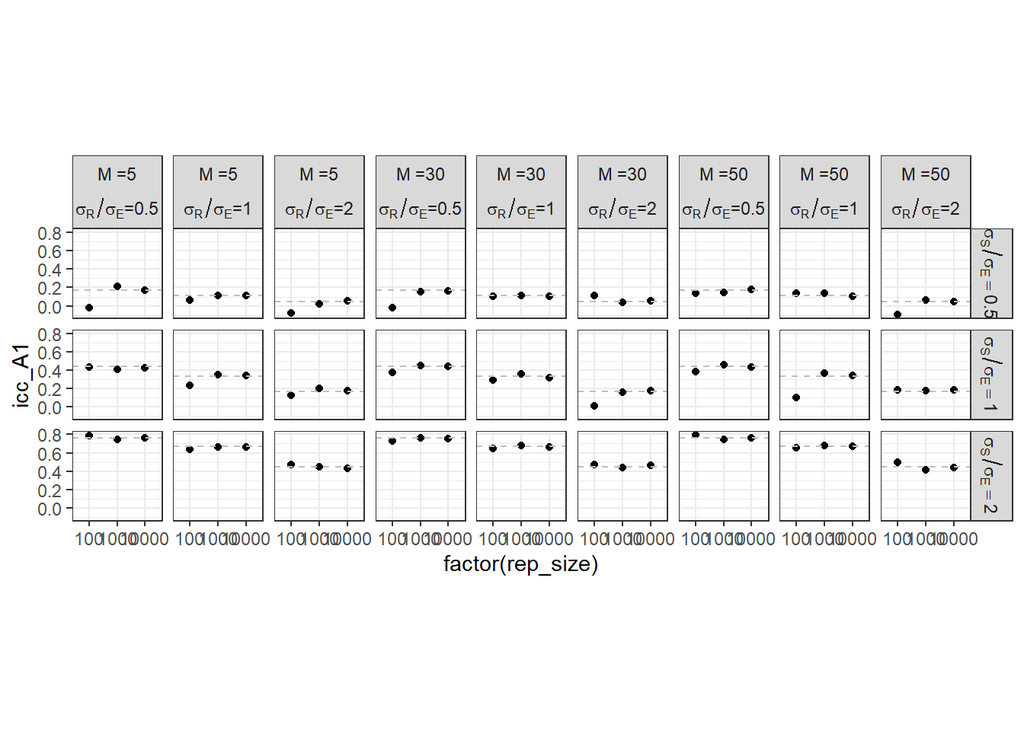

Figure 3: ICC(A, 1) for Case 2

```r
case2_sim |>
  select(rep_size, M, sigma_E, sigma_SE_ratio, sigma_RE_ratio, ICC_A1, icc_A1) |>
  filter(sigma_E == 1) |>
  ggplot(aes(x = factor(rep_size), y = icc_A1)) +
  geom_point() +
  geom_hline(aes(yintercept = ICC_A1), linetype = "dashed", color = "gray") +
  facet_grid(sigma_SE_ratio ~ M + sigma_RE_ratio,
             labeller = label_bquote(rows = sigma[S]/sigma[E] == .(sigma_SE_ratio),
                                     cols = atop(paste("M =", .(M)),
                                                 paste(sigma[R]/sigma[E], "=", .(sigma_RE_ratio)))))
```

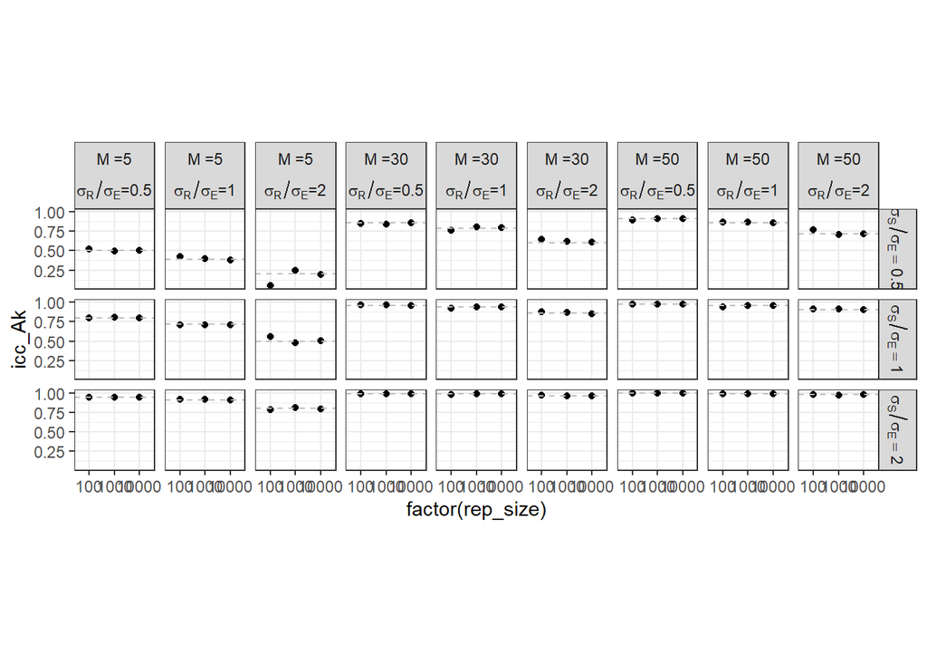

Figure 4: ICC(A, k) for Case 2

```r
case2_sim |>
  select(rep_size, M, sigma_E, sigma_SE_ratio, sigma_RE_ratio, ICC_Ak, icc_Ak) |>
  filter(sigma_E == 1) |>
  ggplot(aes(x = factor(rep_size), y = icc_Ak)) +
  geom_point() +
  geom_hline(aes(yintercept = ICC_Ak), linetype = "dashed", color = "gray") +
  facet_grid(sigma_SE_ratio ~ M + sigma_RE_ratio,
             labeller = label_bquote(rows = sigma[S]/sigma[E] == .(sigma_SE_ratio),
                                     cols = atop(paste("M =", .(M)),
                                                 paste(sigma[R]/sigma[E], "=", .(sigma_RE_ratio)))))
```

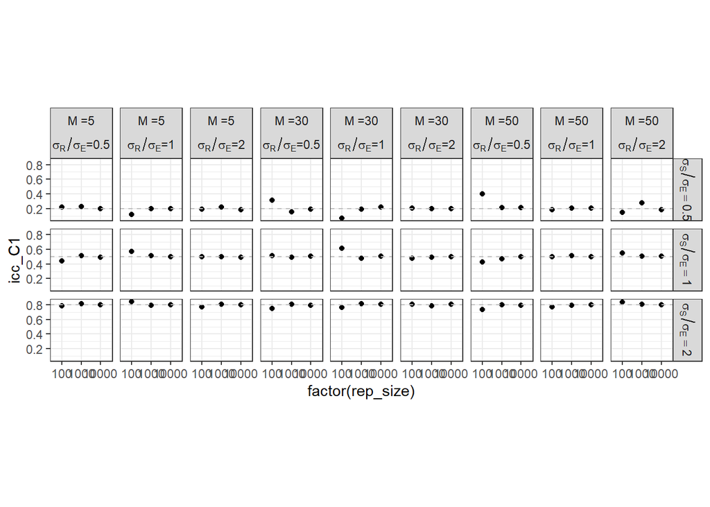

Figure 5: ICC(C, 1) for Case 2

```r
case2_sim |>
  select(rep_size, M, sigma_E, sigma_SE_ratio, sigma_RE_ratio, ICC_C1, icc_C1) |>
  filter(sigma_E == 5) |>
  ggplot(aes(x = factor(rep_size), y = icc_C1)) +
  geom_point() +
  geom_hline(aes(yintercept = ICC_C1), linetype = "dashed", color = "gray") +
  facet_grid(sigma_SE_ratio ~ M + sigma_RE_ratio,
             labeller = label_bquote(rows = sigma[S]/sigma[E] == .(sigma_SE_ratio),
                                     cols = atop(paste("M =", .(M)),
                                                 paste(sigma[R]/sigma[E], "=", .(sigma_RE_ratio)))))
```

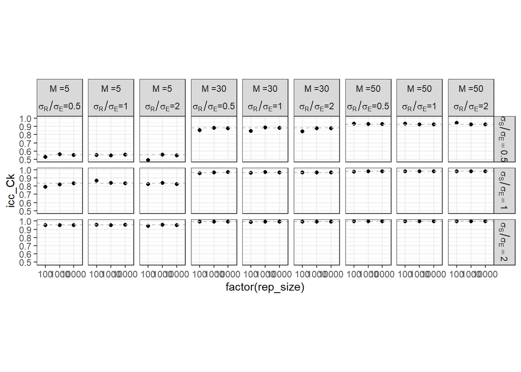

Figure 6: ICC(C, k) for Case 2

```r
case2_sim |>
  select(rep_size, M, sigma_E, sigma_SE_ratio, sigma_RE_ratio, ICC_Ck, icc_Ck) |>
  filter(sigma_E == 5) |>
  ggplot(aes(x = factor(rep_size), y = icc_Ck)) +
  geom_point() +
  geom_hline(aes(yintercept = ICC_Ck), linetype = "dashed", color = "gray") +
  facet_grid(sigma_SE_ratio ~ M + sigma_RE_ratio,
             labeller = label_bquote(rows = sigma[S]/sigma[E] == .(sigma_SE_ratio),
                                     cols = atop(paste("M =", .(M)),
                                                 paste(sigma[R]/sigma[E], "=", .(sigma_RE_ratio)))))
```

## 2.3 Case 3: Two-way Mixed-Effect ANOVA

Subject: $i = 1, \dots, N$, Raters: $j = 1, \dots, M$. Subjects is a random effect while raters is a fixed effect. Subjects and raters are crossed with each other.

$$Y_{ij} = \mu + S_i + R_j + (SR_{ij} + E_{ij}^*) = \mu + S_i + R_j + E_{ij}$$

where

- $S_i \sim N(0, \sigma_S^2)$
- $\sum_{j=1}^M R_j = 0$ and $\theta_R^2 = \frac{1}{M-1} \sum_{j=1}^M R_j^2$
- $E_{ij} \sim N(0, \sigma_E^2)$

and we don’t distinguish the interaction and residual error here.

There is a big issue how could we define ICC(A, 1) and ICC(A, k) for the two-way mixed effect model by the correlation approach. Following our previous manner used in the two-way random effect model, the agreement ICC definitions would be:

$$ICC(A, 1) := Cor(Y_{ij}, Y_{ij'}) = \frac{Cov(Y_{ij}, Y_{ij'})}{\sqrt{Var(Y_{ij}) Var(Y_{ij'})}}$$

The problem is when we calculate the variance of $Y_{ij}$, it should be:

$$Var(Y_{ij}) = Var(\mu + S_i + R_j + E_{ij}) = \sigma_S^2 + \sigma_E^2,$$

not $\sigma_S^2 + \theta_R^2 + \sigma_E^2$ that is the denominator used in the original ICC(A, 1) definition by McGraw & Wong (1996). The reason is that $R_j$ is a fixed effect, not provide any fluctuation. Thus, it does not provide any variance of measurements. Following this, ICC(A, 1) and ICC(A, k) are exactely the same as ICC(C, 1) and ICC(C, k), respectively. I think that is why Shrout & Fleiss (1979) did not define agreement ICC for the two-way mixed effect model.

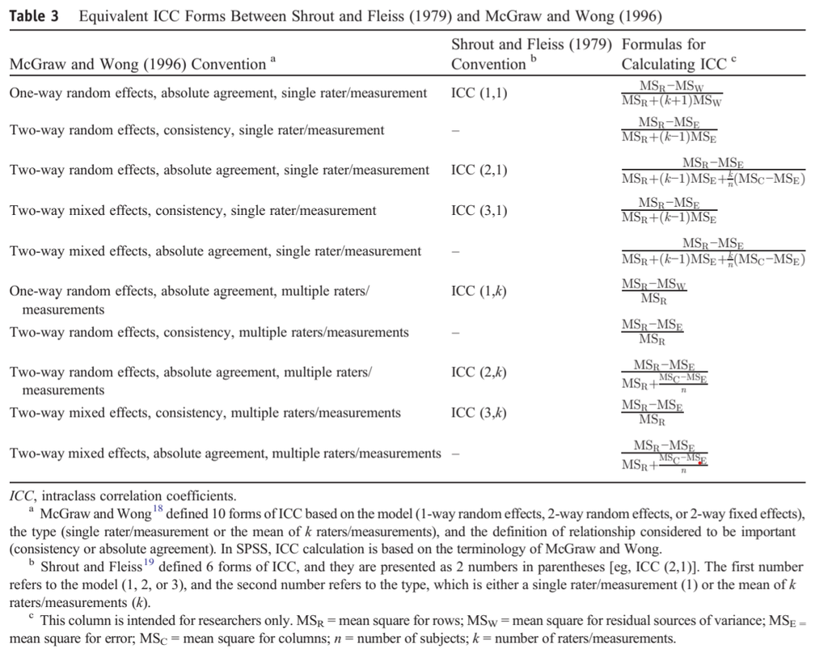

Differences of ICC defnition between Shrout & Fleiss (1979) and McGraw & Wong (1996; Table retrived from Koo & Li, 2016)

Nethertheless, McGraw & Wong (1996) argues that

> Readers familiar with Shrout and Fleiss’s (1979) classic paper on intraclass correlation coefficients will note that ICC(A,1) for mixed effects models (Cases 3 and 3A) and ICCs (C,l) and (C,k) for random effects models (Cases 2 and 2A) were not among the ICCs that Shrout and Fleiss defined. These ICCs were omitted because they are not correlations in the strict sense of being ratios of covariance to total variance. Nonetheless, these ICCs are of considerable practical value for measuring degree of relationship. … Using ICC(A,1) to measure the correlation between parents and children (fixed effects in the model) serves to resolve the different foci of traditional analyses—absolute differences on the one hand and rank order similarities on the otherinto a single measure, one that can be clearly contrasted with a linearity (e.g., r) or additivity (e.g., ICC(C,1)) index. (McGraw & Wong, 1996, pp. 37–38)

My impression is that the authors simply extend the definitions of ICC(A) and ICC(C) from Case 2 to Case 3 by substituting $\theta_R^2$ for $\sigma_R^2$. However, they do not define the ICC strictly as the correlation between two replicates. Furthermore, their use of ICC(A, k) is not explained in detail.

Therefore, if we accept $\theta_R^2 = Var(R_j), \forall j$ as a measure of **dispersion** for the fixed raters under the constraint $\sum_{j=1}^M R_j = 0$, we can then attempt to derive the value of $Cov(R_j, R_{j'})$:

$$\begin{align}
&0 = Var(\sum_{j=1}^M R_j) = \sum_{j=1}^M Var(R_j) + \sum\sum_{j \neq j'}Cov(R_j, R_{j'}) = M\theta_R^2 + M(M-1)Cov(R_j, R_{j'})\\
\implies &Cov(R_j, R_{j'}) = -\frac{1}{M-1}\theta_R^2
\end{align}$$

**Warning**

I know this deriviation has some problems …. If there is no $Var(R_j)$ term, then there is no covariance $Cov(R_j, R_{j'})$

Subsequently, the ICC(A, 1) can be derived as:

$$Cor(Y_{ij}, Y_{ij'}) = \frac{\sigma_S^2 - \frac{1}{M-1}\theta_R^2}{\sigma_S^2 + \theta_R^2 + \sigma_E^2}.$$

comparing to the original definition of McGraw & Wong (1996) ICC(A,1), the above equation additionaly minus $\frac{1}{M-1}\theta_R^2$ in the numerator.

On the other hand, for ICC(A, k), because the average of $R_j$ over the $M$ fixed raters is 0, the variance of the average is also 0 across different replications. Thus, the correlation between two main mean ratings for the same subject $i$ is:

$$\begin{align}
Cor(\bar{Y}_{i\cdot}, \bar{Y}_{i\cdot'})
&= Cor\left(\mu + S_i + \frac{1}{M}\sum_{j=1}^M R_j + \frac{1}{M}\sum_{j=1}^M E_{ij}, \mu + S_i + \frac{1}{M}\sum_{j=1}^M R_j + \frac{1}{M}\sum_{j=1}^M E_{ij'}\right) \\
&= Cor\left(S_i + 0 + \bar{E}_{i\cdot}, S_i + 0 + \bar{E}_{i\cdot'}\right) \\
&= \frac{\sigma_S^2}{\sigma_S^2 + \sigma_E^2 / M} \\
&= ICC(C, k)
\end{align}$$

where $\sum_{j=1}^M R_j = 0 = \sum_{j'=1}^M R_{j'}$ becuase the same set of raters (following the fixed effect definition) is used for both measurements. In contrast, $\frac{1}{M}\sum_{j=1}^M E_{ij} \neq \frac{1}{M}\sum_{j'=1}^M E_{ij'}$ because measurement error are always random even thoughts they are based on the same set of raters.

To some extention, the procedure that I used in our correlation simulation treat the fixed raters as if they are random samples from **a finite population of raters?!**, thus providing some variance and covariance. May be we should rethinking the notation of the random variable, replacing $Y_{ij}$ as $Y_{IJ}$, where $I$ is the index for the subject that can be sampled from the target population and $J$ is the index for the rater that could also be sampled from the population of raters, no matter it is a fixed or random effect.

**Simply check the ICC calculations**

```r
# parameters
M <- 3
sigma_S <- 3
theta_R <- 8
sigma_E <- 2
pars_case3 = list(mu = 2, sigma_S = sigma_S, theta_R = theta_R, sigma_E = sigma_E, M = M)

# results
case3_table <- tibble(
  Reliability = c("ICC(A,1)", "ICC(A,k)", "ICC(C,1)", "ICC(C,k)"),
  Setting = c(
    sigma_S^2 / (sigma_S^2 + theta_R^2 + sigma_E^2),
    sigma_S^2 / (sigma_S^2 + theta_R^2 / M + sigma_E^2 / M),
    sigma_S^2 / (sigma_S^2 + sigma_E^2),
    sigma_S^2 / (sigma_S^2 + sigma_E^2 / M)
  ),
  Setting_corrected = c(
    (sigma_S^2 - theta_R^2 / (M-1)) / (sigma_S^2 + theta_R^2 + sigma_E^2),
    sigma_S^2 / (sigma_S^2 + sigma_E^2 / M),
    sigma_S^2 / (sigma_S^2 + sigma_E^2),
    sigma_S^2 / (sigma_S^2 + sigma_E^2 / M)
  ),
  Simulation = c(
    icc_cor(pars = pars_case3, model = "twoway-mixed", type = "agreement", unit = "single", rep_size = 10000),
    icc_cor(pars = pars_case3, model = "twoway-mixed", type = "agreement", unit = "average", rep_size = 10000),
    icc_cor(pars = pars_case3, model = "twoway-mixed", type = "consistency", unit = "single", rep_size = 10000),
    icc_cor(pars = pars_case3, model = "twoway-mixed", type = "consistency", unit = "average", rep_size = 10000)
  )
) |>
  mutate(across(where(is.numeric), ~ round(., 4)))

gt(case3_table)
```

| Reliability | Setting | Setting_corrected | Simulation |
| --- | --- | --- | --- |
| ICC(A,1) | 0.1169 | -0.2987 | -0.2201 |
| ICC(A,k) | 0.2842 | 0.8710 | 0.8732 |
| ICC(C,1) | 0.6923 | 0.6923 | 0.6969 |
| ICC(C,k) | 0.8710 | 0.8710 | 0.8786 |

**Simulation under different scenarios**

```r
rep_size <- c(100, 1000, 10000)
M <- c(3, 5, 10)
sigma_E <- c(1, 3, 5)
sigma_SE_ratio <- c(0.5, 1, 2)
sigma_RE_ratio <- c(1, 3, 5)

case3_sim <-
  expand_grid(
    rep_size = rep_size,
    M = M,
    sigma_E = sigma_E,
    sigma_SE_ratio = sigma_SE_ratio,
    sigma_RE_ratio = sigma_RE_ratio
  ) |>
  mutate(
    sigma_S = sigma_SE_ratio * sigma_E,
    theta_R = sigma_RE_ratio * sigma_E,
    pars = list_transpose(list(sigma_S = sigma_S, theta_R = theta_R, sigma_E = sigma_E, M = M), simplify = FALSE),
    ICC_A1 = sigma_S^2 / (sigma_S^2 + theta_R^2 + sigma_E^2),
    ICC_Ak = sigma_S^2 / (sigma_S^2 + theta_R^2 / M + sigma_E^2 / M),
    ICC_A1_corrected = (sigma_S^2 - theta_R^2 / (M-1)) / (sigma_S^2 + theta_R^2 + sigma_E^2),
    ICC_Ak_corrected = sigma_S^2 / (sigma_S^2 + sigma_E^2 / M),
    ICC_C1 = sigma_S^2 / (sigma_S^2 + sigma_E^2),
    ICC_Ck = sigma_S^2 / (sigma_S^2 + sigma_E^2 / M),
    icc_A1 = future_map2_dbl(
      pars, rep_size,
      ~ icc_cor(pars = .x, model = "twoway-mixed", type = "agreement",unit = "single", rep_size = .y),
      .options = furrr_options(seed = TRUE)
    ),
    icc_Ak = future_map2_dbl(
      pars, rep_size,
      ~ icc_cor(pars = .x, model = "twoway-mixed", type = "agreement", unit = "average", rep_size = .y),
      .options = furrr_options(seed = TRUE)
    ),
    icc_C1 = future_map2_dbl(
      pars, rep_size,
      ~ icc_cor(pars = .x, model = "twoway-mixed", type = "consistency", unit = "single", rep_size = .y),
      .options = furrr_options(seed = TRUE)
    ),
    icc_Ck = future_map2_dbl(
      pars, rep_size,
      ~ icc_cor(pars = .x, model = "twoway-mixed", type = "consistency",unit = "average", rep_size = .y),
      .options = furrr_options(seed = TRUE)
    )
  )
```

Gray dotted line is the original ICC(A, 1) and blue dotted line is the corrected ICC(A, 1).

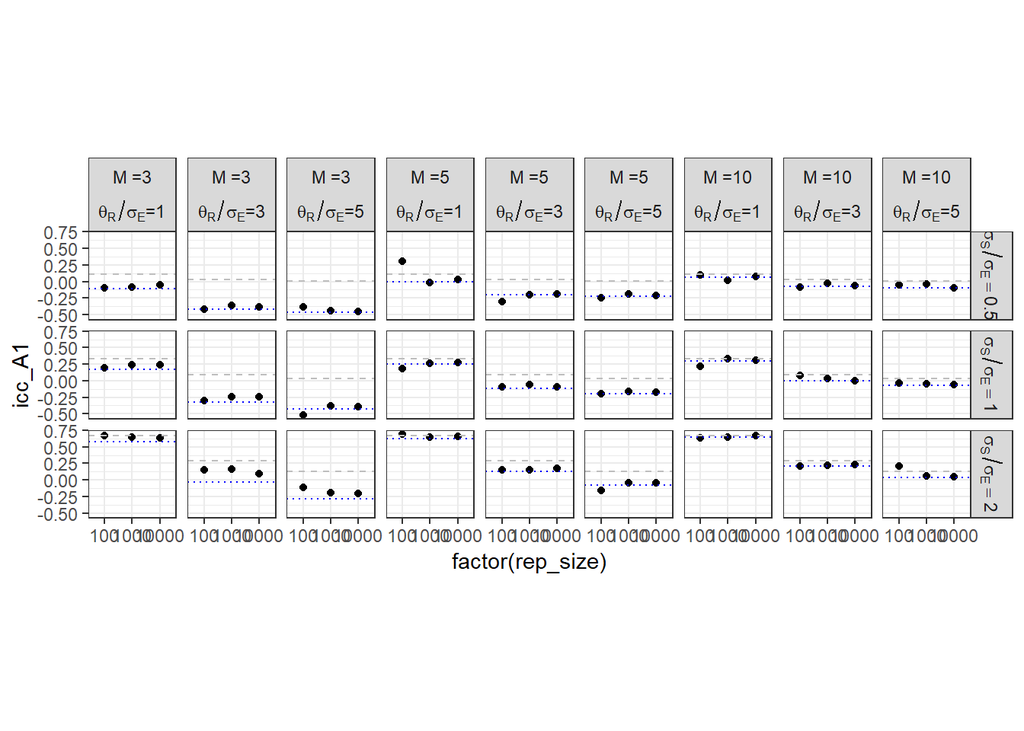

Figure 7: ICC(A, 1) for Case 3

```r
case3_sim |>
  select(rep_size, M, sigma_E, sigma_SE_ratio, sigma_RE_ratio, ICC_A1, ICC_A1_corrected, icc_A1) |>
  filter(sigma_E == 1) |>
  ggplot(aes(x = factor(rep_size), y = icc_A1)) +
  geom_point() +
  geom_hline(aes(yintercept = ICC_A1), linetype = "dashed", color = "gray") +
  geom_hline(aes(yintercept = ICC_A1_corrected), linetype = "dotted", color = "blue") +
  facet_grid(sigma_SE_ratio ~ M + sigma_RE_ratio,
             labeller = label_bquote(rows = sigma[S]/sigma[E] == .(sigma_SE_ratio),
                                     cols = atop(paste("M =", .(M)),
                                                 paste(theta[R]/sigma[E], "=", .(sigma_RE_ratio)))))
```

Gray dotted line is the original ICC(A, k) and blue dotted line is the corrected ICC(A, k) = ICC(C, k).

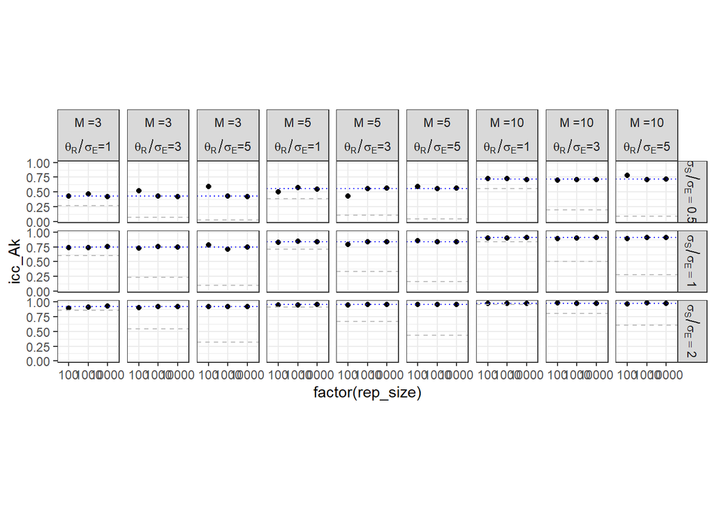

Figure 8: ICC(A, k) for Case 3

```r
case3_sim |>
  select(rep_size, M, sigma_E, sigma_SE_ratio, sigma_RE_ratio, ICC_Ak, ICC_Ak_corrected, icc_Ak) |>
  filter(sigma_E == 1) |>
  ggplot(aes(x = factor(rep_size), y = icc_Ak)) +
  geom_point() +
  geom_hline(aes(yintercept = ICC_Ak), linetype = "dashed", color = "gray") +
  geom_hline(aes(yintercept = ICC_Ak_corrected), linetype = "dotted", color = "blue") +

  facet_grid(sigma_SE_ratio ~ M + sigma_RE_ratio,
             labeller = label_bquote(rows = sigma[S]/sigma[E] == .(sigma_SE_ratio),
                                     cols = atop(paste("M =", .(M)),
                                                 paste(theta[R]/sigma[E], "=", .(sigma_RE_ratio)))))
```

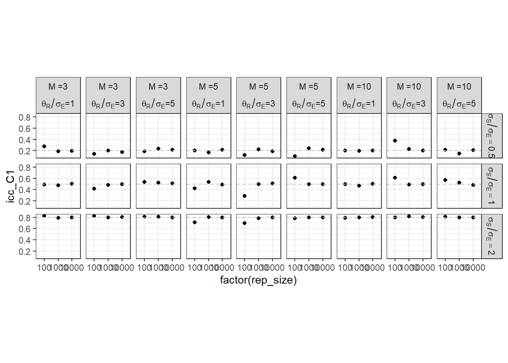

Figure 9: ICC(C, 1) for Case 3

```r
case3_sim |>
  select(rep_size, M, sigma_E, sigma_SE_ratio, sigma_RE_ratio, ICC_C1, icc_C1) |>
  filter(sigma_E == 1) |>
  ggplot(aes(x = factor(rep_size), y = icc_C1)) +
  geom_point() +
  geom_hline(aes(yintercept = ICC_C1), linetype = "dashed", color = "gray") +
  facet_grid(sigma_SE_ratio ~ M + sigma_RE_ratio,
             labeller = label_bquote(rows = sigma[S]/sigma[E] == .(sigma_SE_ratio),
                                     cols = atop(paste("M =", .(M)),
                                                 paste(theta[R]/sigma[E], "=", .(sigma_RE_ratio)))))
```

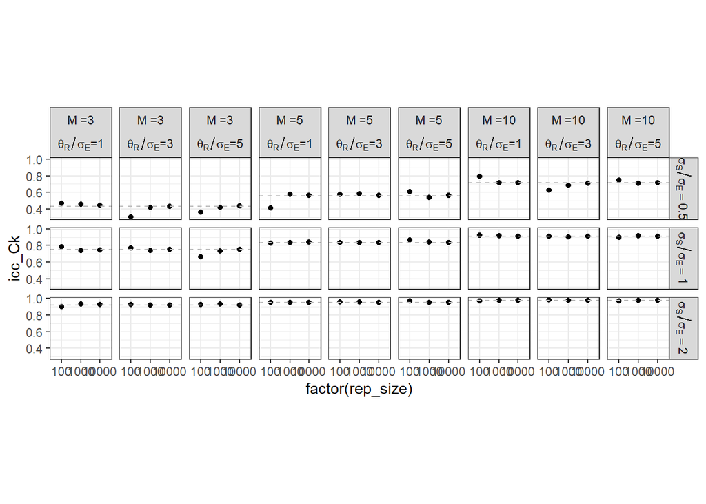

Figure 10: ICC(C, k) for Case 3

```r
case3_sim |>
  select(rep_size, M, sigma_E, sigma_SE_ratio, sigma_RE_ratio, ICC_Ck, icc_Ck) |>
  filter(sigma_E == 1) |>
  ggplot(aes(x = factor(rep_size), y = icc_Ck)) +
  geom_point() +
  geom_hline(aes(yintercept = ICC_Ck), linetype = "dashed", color = "gray") +
  facet_grid(sigma_SE_ratio ~ M + sigma_RE_ratio,
             labeller = label_bquote(rows = sigma[S]/sigma[E] == .(sigma_SE_ratio),
                                     cols = atop(paste("M =", .(M)),
                                                 paste(theta[R]/sigma[E], "=", .(sigma_RE_ratio)))))
```